# Support Vector Machine

Machine Learning

R code using Various Kernel Function for Support Vector Machine

Yeongeun Jeon , Jeongwook Lee , Jung In Seo  
09-28-2020

> 서포트 벡터 머신을 사용할 수 있는 대표적인 패키지는 `"e1071"`과 `"kernlab"`이다. `"kernlab"`는 `"e1071"`의 확장된 형태이며, 다양한 커널 함수를 사용할 수 있다.  
> 예제 데이터는 “Universal Bank_Main”로 유니버셜 은행의 고객들에 대한 데이터(출처 : Data Mining for Business Intelligence, Shmueli et al. 2010)이다. 데이터는 총 2500개이며, 변수의 갯수는 13개이다. 여기서 **Target**은 `Person.Loan`이다.

# **1. 데이터 불러오기**

```
pacman::p_load("data.table", "dplyr")

UB <- fread(paste(getwd(),"Universal Bank_Main.csv", sep="/")) %>%  # 데이터 불러오기
  data.frame()                                                      # Data Frame 변환환


cols <- c("Family", "Education", "Personal.Loan",
          "Securities.Account", "CD.Account", "Online", "CreditCard")

UB <- UB %>%
  select(-1) %>%                                                    # 1열 제거거
  mutate_at(cols, factor)                                           # 범주형 변수 변환

glimpse(UB)                                                         # 데이터 구조
```

```
Rows: 2,500
Columns: 13
$ Age                <int> 25, 45, 39, 35, 35, 37, 53, 50, 35, 34, 6~
$ Experience         <int> 1, 19, 15, 9, 8, 13, 27, 24, 10, 9, 39, 5~
$ Income             <int> 49, 34, 11, 100, 45, 29, 72, 22, 81, 180,~
$ ZIP.Code           <int> 91107, 90089, 94720, 94112, 91330, 92121,~
$ Family             <fct> 4, 3, 1, 1, 4, 4, 2, 1, 3, 1, 4, 3, 2, 4,~
$ CCAvg              <dbl> 1.6, 1.5, 1.0, 2.7, 1.0, 0.4, 1.5, 0.3, 0~
$ Education          <fct> 1, 1, 1, 2, 2, 2, 2, 3, 2, 3, 3, 2, 3, 2,~
$ Mortgage           <int> 0, 0, 0, 0, 0, 155, 0, 0, 104, 0, 0, 0, 0~
$ Personal.Loan      <fct> 0, 0, 0, 0, 0, 0, 0, 0, 0, 1, 0, 0, 0, 0,~
$ Securities.Account <fct> 1, 1, 0, 0, 0, 0, 0, 0, 0, 0, 0, 0, 1, 0,~
$ CD.Account         <fct> 0, 0, 0, 0, 0, 0, 0, 0, 0, 0, 0, 0, 0, 0,~
$ Online             <fct> 0, 0, 0, 0, 0, 1, 1, 0, 1, 0, 0, 1, 0, 1,~
$ CreditCard         <fct> 0, 0, 0, 0, 1, 0, 0, 1, 0, 0, 0, 0, 0, 0,~
```

# **2. 데이터 분할**

```
pacman::p_load("caret")
# Partition (Traning Data : Test Data = 7:3)
y      <- UB$Personal.Loan                       # Target

set.seed(200)
ind    <- createDataPartition(y, p=0.7, list=F)  # Training Data를 70% 추출
UB.trd <- UB[ind,]                               # Traning Data

UB.ted <- UB[-ind,]                              # Test Data

detach(package:caret)
```

# **3. R Package “e1071”**

Package `"e1071"`은 `"svm"` 함수로 서포트 벡터 머신을 사용할 수 있다. 자세한 옵션은 [여기를 참조한다.](https://www.rdocumentation.org/packages/e1071/versions/1.7-3/topics/svm)

```
svm(formula, data, kernel , cost, cross, probability, ...)
```

- `formula` : Target과 예측 변수에 대한 공식으로써 일반적으로 `Target ~ 예측변수` 사용
- `data` : `formula`의 변수들이 있는 데이터 프레임
- `kernel` : Kernel 함수로 default 값은 “radial”
- `cost` : 과적합을 막는 정도를 지정하는 모수로 데이터를 잘못 분류하는 선을 긋게 될 경우 얼마만큼의 비용(cost)을 지불할 것인지 지정하며, default 값은 “1”
- `cross` : Cross validation의 fold 수로 training data의 정확도를 출력
- `probability` : `TRUE` 일 때 test data에 대하여 예측 확률 출력 가능

## **3-1. Linear Kernel**

### **3-1-1. 모형 적합**

```
pacman::p_load("e1071")


set.seed(200)
svm.model.li <- svm(Personal.Loan~.,
                    data=UB.trd,
                    cost=1,
                    cross=10,
                    kernel="linear",     # kernel = "linear" (Linear Kernel)
                    probability = T)


summary(svm.model.li)
```

```
Call:
svm(formula = Personal.Loan ~ ., data = UB.trd, cost = 1,
    cross = 10, kernel = "linear", probability = T)


Parameters:
   SVM-Type:  C-classification
 SVM-Kernel:  linear
       cost:  1

Number of Support Vectors:  199

 ( 101 98 )


Number of Classes:  2

Levels:
 0 1

10-fold cross-validation on training data:

Total Accuracy: 95.77384
Single Accuracies:
 97.14286 96 93.71429 95.42857 95.42857 93.14286 98.85714 96 94.28571 97.72727
```

- 총 서포트 벡터의 수는 199개이며, 클래스 “0”에서 101개, 클래스 “1”에서는 98개이다.

```
svm.model.li$index   # Support Vector
```

```
  [1]    9   48   68  108  109  123  147  156  157  203  205  221  228
 [14]  230  294  299  311  323  352  366  373  384  413  430  433  452
 [27]  476  525  532  560  582  614  626  643  645  760  767  781  784
 [40]  845  846  853  863  870  876  880  883  890  899  904  920  936
 [53]  953  960  996 1036 1056 1061 1083 1095 1113 1121 1130 1190 1193
 [66] 1197 1201 1202 1226 1252 1254 1259 1274 1309 1318 1324 1327 1336
 [79] 1340 1359 1365 1384 1387 1395 1400 1408 1421 1430 1436 1476 1530
 [92] 1588 1600 1619 1621 1637 1666 1669 1706 1714 1715   14   24   34
[105]   46   69  110  115  128  210  219  220  224  225  226  246  268
[118]  277  293  305  308  359  375  380  436  455  458  472  493  517
[131]  539  541  547  567  583  622  664  670  672  679  708  715  720
[144]  727  742  782  783  794  796  809  816  829  861  887  909  916
[157]  951  952  978  979 1045 1059 1090 1100 1103 1107 1110 1122 1131
[170] 1154 1170 1172 1175 1213 1241 1253 1257 1260 1262 1281 1284 1308
[183] 1317 1326 1342 1403 1429 1504 1505 1585 1586 1622 1630 1654 1674
[196] 1680 1689 1709 1713
```

### **3-1-2. 최적 모수 찾기**

함수 `"svm"`은 cross validation을 통해 최적의 모수를 찾을 수 있으며 `"tune"` 함수를 이용한다.

```
tune(method, train.x, train.y, data, ranges , ...) # Version 1
tune(method, formula, data, ranges , ...)          # Version 2
```

- `method` : 최적화할 함수
- `train.x` : formula 또는 예측 변수의 행렬
- `train.y` : 만약 `train.x`가 formula일 경우 무시해도 되며, 예측 변수일 경우 Target
- `formula` : Target과 예측 변수에 대한 공식으로써 일반적으로 `Target ~ 예측변수` 사용
- `data` : 변수들이 있는 데이터 프레임
- `range` : 최적화할 모수들의 후보값으로써 리스트 형태

```
set.seed(200)
tn.control  <- tune.control(cross=10)        # Number of Partitions For Cross Validation
tune.svm.li <- tune(svm, Personal.Loan~., data=UB.trd, kernel="linear",
                    ranges=list(cost=c(0.1,1,10)), tunecontrol=tn.control)

summary(tune.svm.li)
```

```
Parameter tuning of 'svm':

- sampling method: 10-fold cross validation

- best parameters:
 cost
    1

- best performance: 0.03825974

- Detailed performance results:
  cost      error dispersion
1  0.1 0.04225974 0.01479686
2  1.0 0.03825974 0.01204431
3 10.0 0.03883117 0.01564838
```

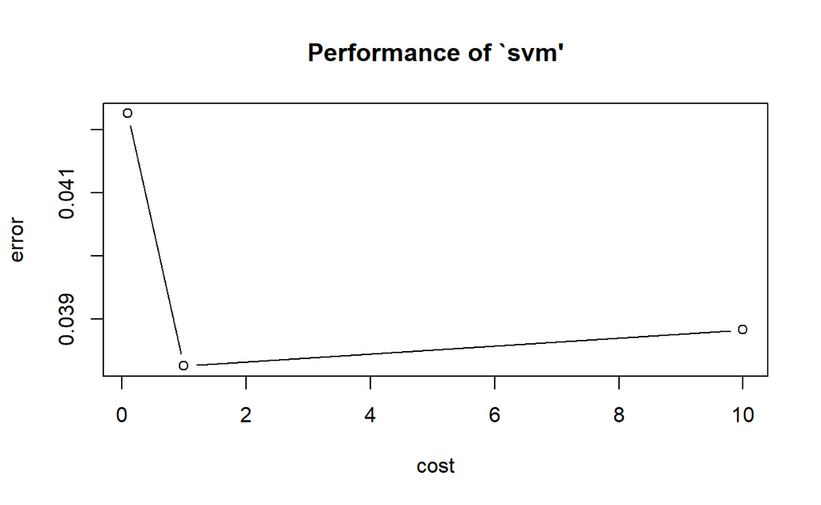

```
plot(tune.svm.li)
```

- `cost`가 1일 때 오차가 가장 작은 것을 알 수 있다.

```
# 최적의 모수를 이용한 최종 모형 NAset.seed(200)
svm.li.best <- svm(Personal.Loan~.,
                   data=UB.trd,
                   cost=1,
                   cross=10,
                   kernel="linear",
                   probability=T)


summary(svm.li.best)
```

```
Call:
svm(formula = Personal.Loan ~ ., data = UB.trd, cost = 1,
    cross = 10, kernel = "linear", probability = T)


Parameters:
   SVM-Type:  C-classification
 SVM-Kernel:  linear
       cost:  1

Number of Support Vectors:  199

 ( 101 98 )


Number of Classes:  2

Levels:
 0 1

10-fold cross-validation on training data:

Total Accuracy: 95.77384
Single Accuracies:
 97.14286 96 93.71429 95.42857 95.42857 93.14286 98.85714 96 94.28571 97.72727
```

### **3-1-3. 모형 평가**

```
# 적합된 모형에 대하여 Test Data 예측NAsvm.li.best.pred <- predict(svm.li.best, newdata=UB.ted, probability=T)        # predict(svm모형, Test Data)
```

#### **ConfusionMatrix**

```
pacman::p_load("caret")


confusionMatrix(svm.li.best.pred, UB.ted$Personal.Loan, positive="1")  # confusionMatrix(예측 클래스, 실제 클래스, positive = "관심 클래스") 클래스")
```

```
Confusion Matrix and Statistics

          Reference
Prediction   0   1
         0 666  28
         1   7  48

               Accuracy : 0.9533
                 95% CI : (0.9356, 0.9672)
    No Information Rate : 0.8985
    P-Value [Acc > NIR] : 3.36e-08

                  Kappa : 0.7079

 Mcnemar's Test P-Value : 0.0007232

            Sensitivity : 0.63158
            Specificity : 0.98960
         Pos Pred Value : 0.87273
         Neg Pred Value : 0.95965
             Prevalence : 0.10147
         Detection Rate : 0.06409
   Detection Prevalence : 0.07343
      Balanced Accuracy : 0.81059

       'Positive' Class : 1
```

```
detach(package:caret)
```

#### **ROC 곡선**

##### **1) Package “pROC”**

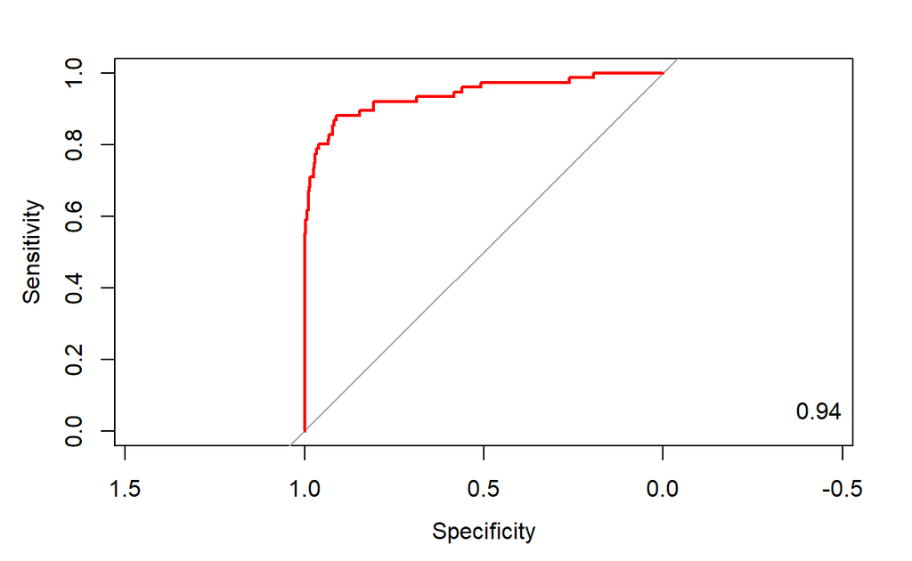

```
pacman::p_load("pROC")

ac <- UB.ted$Personal.Loan                                   # 실제 클래스래스
pp <- attr(svm.li.best.pred, "probabilities")[,2]            # "1"에 대한 예측 확률


svm.li.roc <- roc(ac, pp, plot=T, col="red")                 # roc(실제 클래스, 예측 확률)률)

auc <- round(auc(svm.li.roc), 3)                             # AUC
legend("bottomright",legend=auc, bty="n")
```

```
detach(package:pROC)
```

##### **2) Package “Epi”**

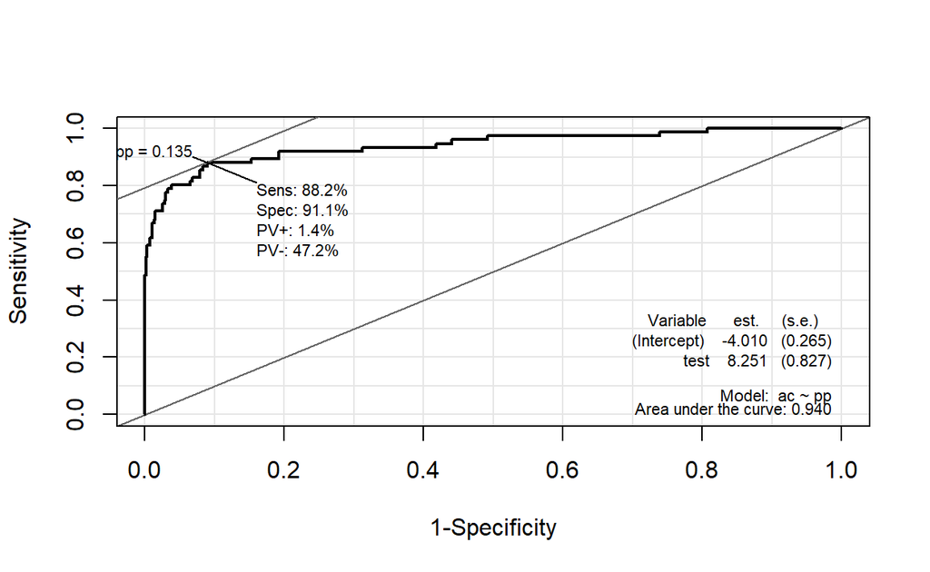

```
# install.packages("Epi")
pacman::p_load("Epi")
# install_version("etm", version = "1.1", repos = "http://cran.us.r-project.org")

ROC(pp,ac, plot="ROC")       # ROC(예측 확률 , 실제 클래스)
```

```
detach(package:Epi)
```

##### **3) Package “ROCR”**

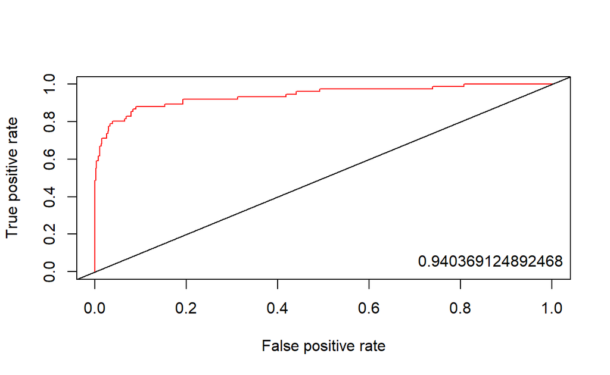

```
pacman::p_load("ROCR")

svm.li.pred <- prediction(pp, ac)                        # prediction(예측 확률, 실제 클래스)스)

svm.li.perf <- performance(svm.li.pred, "tpr", "fpr")    # performance(, "민감도", "1-특이도")
plot(svm.li.perf, col="red")                             # ROC Curve
abline(0,1, col="black")


perf.auc <- performance(svm.li.pred, "auc")              # AUC

auc <- attributes(perf.auc)$y.values
legend("bottomright",legend=auc,bty="n")
```

#### **향상 차트**

##### **1) Package “ROCR”**

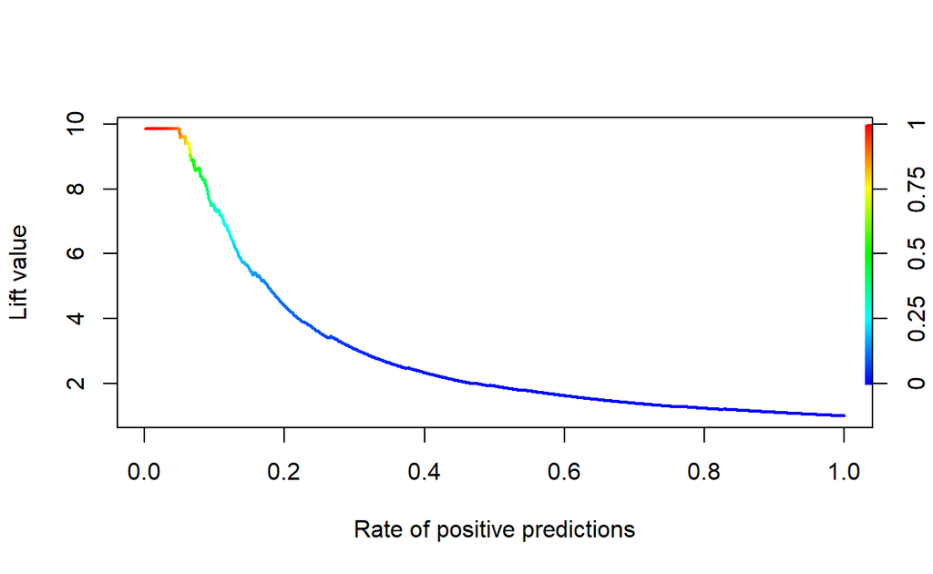

```
li.lift <- performance(svm.li.pred,"lift", "rpp")       # Lift chart
plot(li.lift, colorize=T, lwd=2)
```

```
detach(package:ROCR)
```

##### **2) Package “lift”**

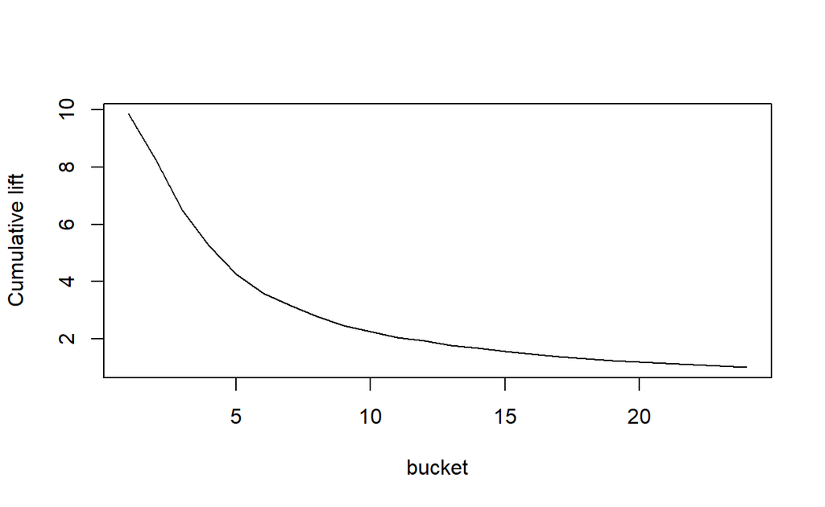

```
# install.packages("lift")
pacman::p_load("lift")

plotLift(pp, ac, cumulative = T, n.buckets =24)      # plotLift(예측 확률, 실제 클래스)스)
```

```
TopDecileLift(pp, ac)                                # Top 10% 향상도 출력
```

```
[1] 7.359
```

```
detach(package:lift)
```

## **3-2. Radial Basis Kernel**

### **3-2-1. 모형 적합**

```
set.seed(200)
svm.model.nl <- svm(Personal.Loan~.,
                    data=UB.trd,
                    gamma=1,             # gamma : 가우시안 커널의 모수로써, 가우시안 커널의 폭을 제어하는 매개 변수
                    cost=1,
                    cross=10,
                    kernel="radial",     # 비선형 옵션 “radial” (가우시안 커널)커널)
                    probability = T)


summary(svm.model.nl)
```

```
Call:
svm(formula = Personal.Loan ~ ., data = UB.trd, gamma = 1,
    cost = 1, cross = 10, kernel = "radial", probability = T)


Parameters:
   SVM-Type:  C-classification
 SVM-Kernel:  radial
       cost:  1

Number of Support Vectors:  1397

 ( 1217 180 )


Number of Classes:  2

Levels:
 0 1

10-fold cross-validation on training data:

Total Accuracy: 89.77727
Single Accuracies:
 91.42857 89.14286 90.28571 90.28571 93.14286 87.42857 89.71429 88.57143 85.71429 92.04545
```

- 총 서포트 벡터의 수는 1397개이며, 클래스 “0”에서 1217개, 클래스 “1”에서는 180개이다.

```
svm.model.nl$index   # Support Vector
```

```
   [1]    1    2    3    4    7    9   10   11   13   15   17   18
  [13]   19   20   21   22   23   26   27   28   29   30   31   35
  [25]   36   37   39   40   41   42   44   45   47   48   49   50
  [37]   51   52   53   55   56   57   58   59   60   61   62   63
  [49]   65   66   68   72   73   74   76   77   79   80   82   84
  [61]   85   86   88   89   90   91   92   93   94   95   97   99
  [73]  101  102  103  104  105  106  107  108  109  111  114  117
  [85]  119  120  121  122  123  124  125  126  127  131  132  133
  [97]  134  135  137  139  140  141  144  146  147  148  149  151
 [109]  152  154  156  157  158  160  161  163  164  165  166  167
 [121]  171  173  174  175  176  177  178  179  180  181  182  184
 [133]  185  188  189  190  191  192  194  195  196  197  198  201
 [145]  202  203  206  208  209  211  212  213  214  215  216  217
 [157]  218  221  222  223  227  228  230  233  235  240  241  242
 [169]  243  244  247  249  251  254  255  257  258  259  260  261
```

[output cut: 102 more lines]

### **3-2-2. 최적 모수 찾기**

```
set.seed(200)
tn.control  <- tune.control(cross=10)          # Number of Partitions For Cross Validation
tune.svm.nl <- tune(svm, Personal.Loan~., data=UB.ted, kernel="radial",
                    ranges=list(gamma=c(0.1,1,10), cost=c(0.1,1,10)), tunecontrol=tn.control)

summary(tune.svm.nl)
```

```
Parameter tuning of 'svm':

- sampling method: 10-fold cross validation

- best parameters:
 gamma cost
   0.1   10

- best performance: 0.03736937

- Detailed performance results:
  gamma cost      error dispersion
1   0.1  0.1 0.10149550 0.03944150
2   1.0  0.1 0.10149550 0.03944150
3  10.0  0.1 0.10149550 0.03944150
4   0.1  1.0 0.05340541 0.02084754
5   1.0  1.0 0.10149550 0.03944150
6  10.0  1.0 0.10149550 0.03944150
7   0.1 10.0 0.03736937 0.01510942
8   1.0 10.0 0.09882883 0.03577778
9  10.0 10.0 0.10149550 0.03944150
```

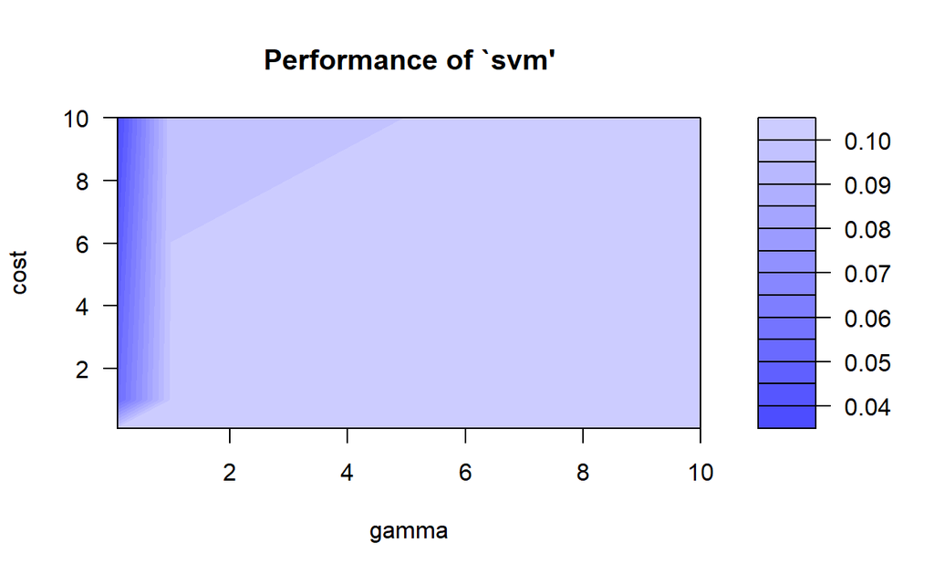

```
plot(tune.svm.nl)
```

- `gamma` = 0.1, `cost` = 10일 때 error가 가장 작다.

```
# 최적의 모수를 이용한 최종 모형NAset.seed(200)
svm.nl.best <- svm(Personal.Loan~.,
                   data=UB.trd,
                   gamma=0.1,
                   cost=10,
                   cross=10,
                   kernel="radial",
                   probability=T)


summary(svm.nl.best)
```

```
Call:
svm(formula = Personal.Loan ~ ., data = UB.trd, gamma = 0.1,
    cost = 10, cross = 10, kernel = "radial", probability = T)


Parameters:
   SVM-Type:  C-classification
 SVM-Kernel:  radial
       cost:  10

Number of Support Vectors:  235

 ( 143 92 )


Number of Classes:  2

Levels:
 0 1

10-fold cross-validation on training data:

Total Accuracy: 97.2016
Single Accuracies:
 98.85714 97.14286 96.57143 98.85714 97.71429 96 97.14286 96.57143 94.28571 98.86364
```

### **3-2-3. 모형 평가**

```
# 적합된 모형에 대하여 Test Data 예측NAsvm.nl.best.pred <- predict(svm.nl.best, newdata=UB.ted, probability=T)  # predict(svm모형, Test Data)
```

#### **ConfusionMatrix**

```
pacman::p_load("caret")


confusionMatrix(svm.nl.best.pred, UB.ted$Personal.Loan, positive="1")    # confusionMatrix(예측 클래스, 실제 클래스, positive = "관심 클래스") 클래스")
```

```
Confusion Matrix and Statistics

          Reference
Prediction   0   1
         0 668  17
         1   5  59

               Accuracy : 0.9706
                 95% CI : (0.9559, 0.9815)
    No Information Rate : 0.8985
    P-Value [Acc > NIR] : 3.493e-14

                  Kappa : 0.8268

 Mcnemar's Test P-Value : 0.01902

            Sensitivity : 0.77632
            Specificity : 0.99257
         Pos Pred Value : 0.92188
         Neg Pred Value : 0.97518
             Prevalence : 0.10147
         Detection Rate : 0.07877
   Detection Prevalence : 0.08545
      Balanced Accuracy : 0.88444

       'Positive' Class : 1
```

```
detach(package:caret)
```

#### **ROC 곡선**

##### **1) Package “pROC”**

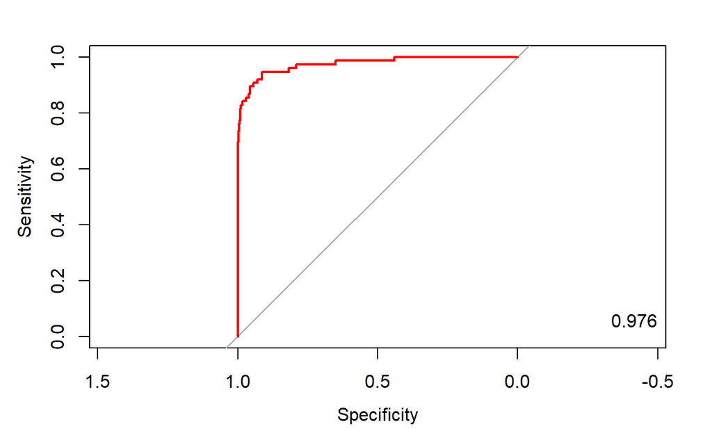

```
pacman::p_load("pROC")

ac <- UB.ted$Personal.Loan                                   # 실제 클래스래스
pp <- attr(svm.nl.best.pred, "probabilities")[,2]            # "1"에 대한 예측 확률


svm.nl.roc <- roc(ac, pp, plot=T, col="red")                 # roc(실제 클래스, 예측 확률)률)

auc <- round(auc(svm.nl.roc), 3)                             # AUC
legend("bottomright",legend=auc, bty="n")
```

```
detach(package:pROC)
```

##### **2) Package “Epi”**

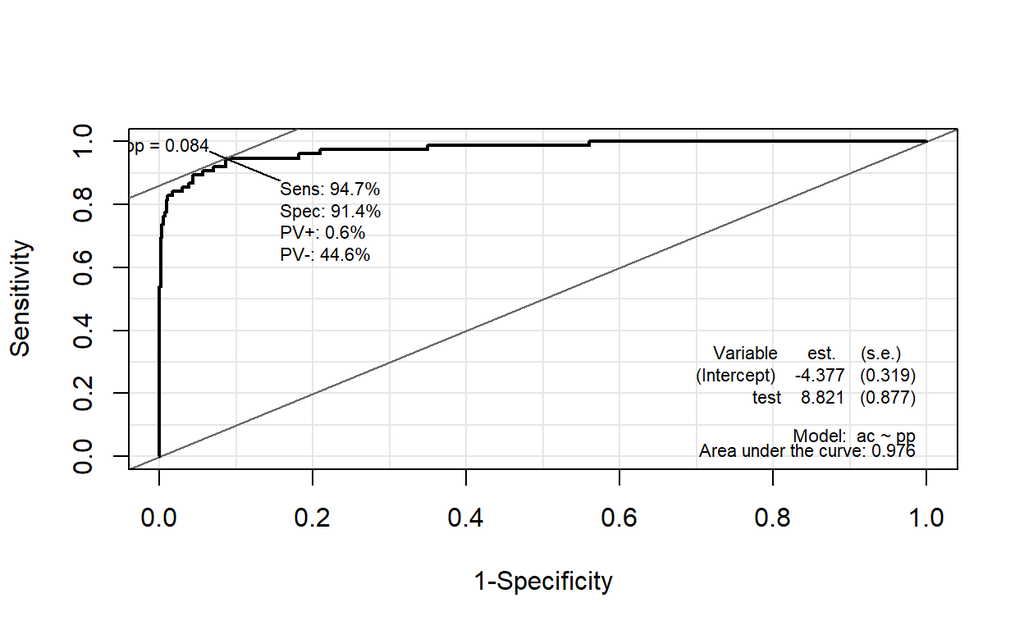

```
# install.packages("Epi")
pacman::p_load("Epi")
# install_version("etm", version = "1.1", repos = "http://cran.us.r-project.org")

ROC(pp,ac, plot="ROC")       # ROC(예측 확률 , 실제 클래스)
```

```
detach(package:Epi)
```

##### **3) Package “ROCR”**

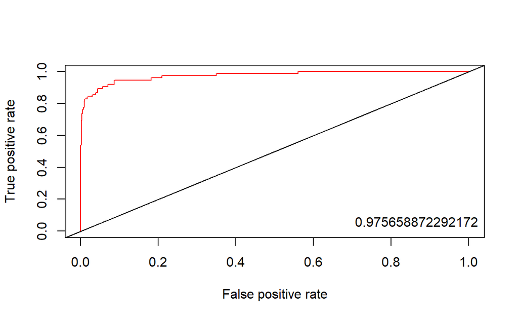

```
pacman::p_load("ROCR")

svm.nl.pred <- prediction(pp, ac)                        # prediction(예측 확률, 실제 클래스)스)

svm.nl.perf <- performance(svm.nl.pred, "tpr", "fpr")    # performance(, "민감도", "1-특이도")
plot(svm.nl.perf, col="red")                             # ROC Curve
abline(0,1, col="black")


perf.auc <- performance(svm.nl.pred, "auc")              # AUC

auc <- attributes(perf.auc)$y.values
legend("bottomright",legend=auc,bty="n")
```

#### **향상 차트**

##### **1) Package “ROCR”**

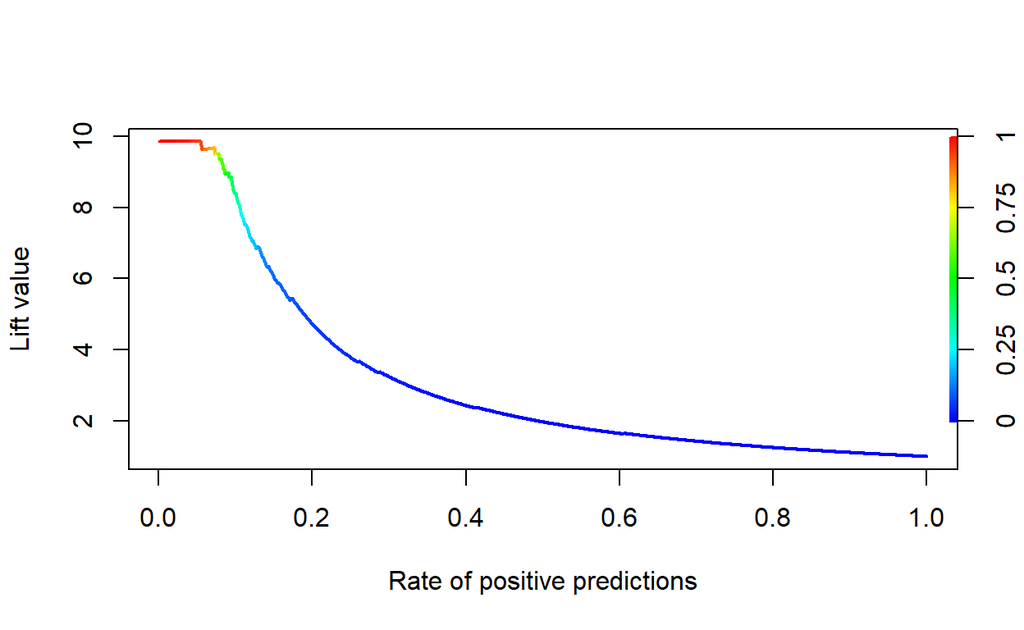

```
nl.lift <- performance(svm.nl.pred,"lift", "rpp")       # Lift chart
plot(nl.lift, colorize=T, lwd=2)
```

```
detach(package:ROCR)
```

##### **2) Package “lift”**

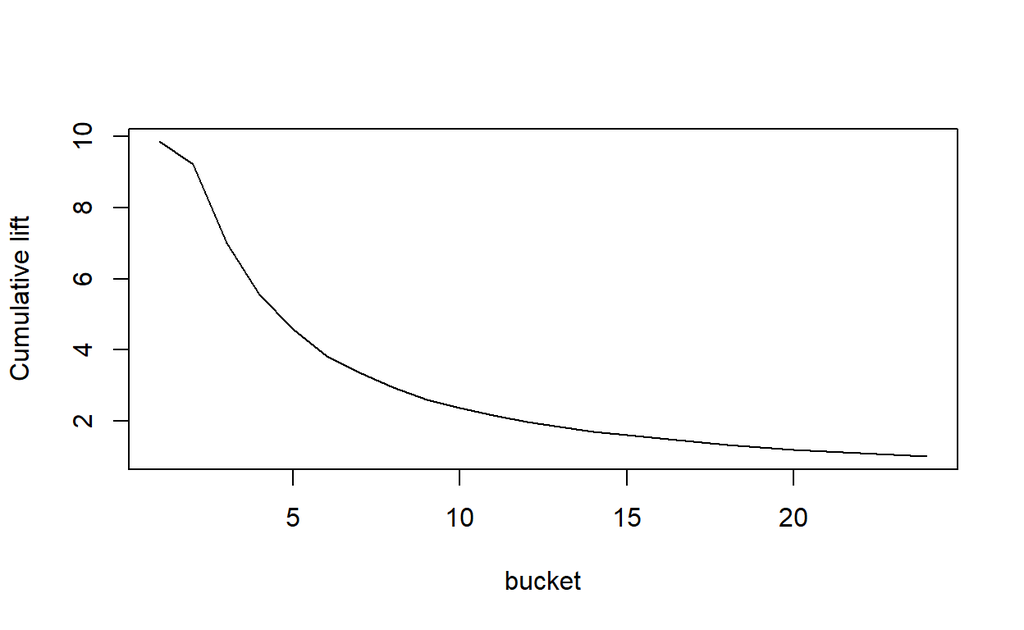

```
# install.packages("lift")
pacman::p_load("lift")

plotLift(pp, ac, cumulative = T, n.buckets =24)      # plotLift(예측 확률, 실제 클래스)스)
```

```
TopDecileLift(pp, ac)                                # Top 10% 향상도 출력
```

```
[1] 8.41
```

```
detach(package:lift)
```

## **3-3. 모형 비교**

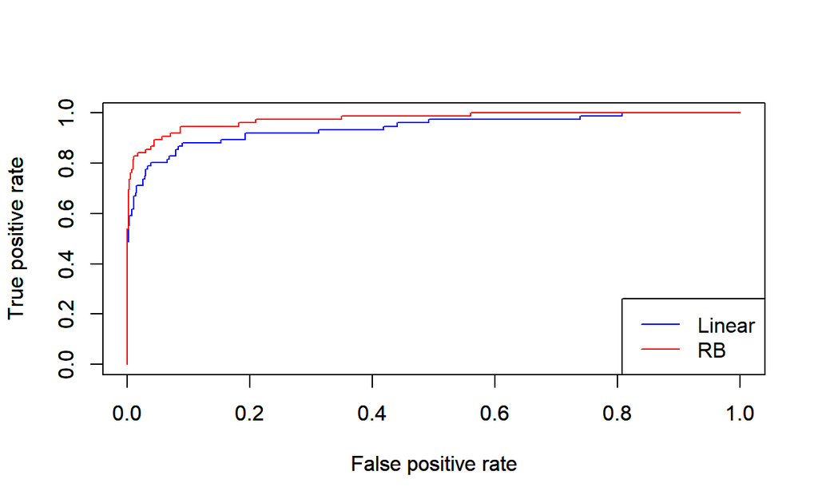

```
plot(svm.li.perf, col="blue")         # ROC Curve
par(new=TRUE)
plot(svm.nl.perf, col="red")          # ROC Curve

legend("bottomright", legend=c("Linear", "RB"), col=c("blue", "red"), lty=c(1,1))
```

- Radial Basis Kernel이 더 우수한 것을 알 수 있다.

# **4. R Package “kernlab”**

Package `"kernlab"`은 `"ksvm"` 함수로 서포트 벡터 머신을 사용할 수 있다. `"ksvm"`의 장점은 Kernel 함수가 `"rbfdot"`인 경우 자동적으로 최적의 `gamma`값을 찾아준다. 자세한 옵션은 [여기를 참조한다.](https://www.rdocumentation.org/packages/kernlab/versions/0.9-29/topics/ksvm)

```
ksvm(x, data, y, kernel , C, cross, prob.model, ...)      # Version 1
ksvm(formula, data, kernel , C, cross, prob.model, ...)   # Version 2
```

- `x` : formula 또는 예측 변수의 행렬
- `formula` : Target과 예측 변수에 대한 공식으로써 일반적으로 `Target ~ 예측변수` 사용
- `data` : `formula`의 변수들이 있는 데이터 프레임
- `y` : 만약 `x`가 formula 경우 무시해도 되며, 예측 변수일 경우 Target
- `kernel` : Kernel 함수로 default 값은 “rbfdot”
- `C` : 과적합을 막는 정도를 지정하는 모수로 데이터를 잘못 분류하는 선을 긋게 될 경우 얼마만큼의 비용(cost)을 지불할 것인지 지정하며, default 값은 “1”
- `cross` : Cross validation의 fold 수로 cross validation error를 출력
- `prob.model` : `TRUE` 일 때 데이터에 대하여 3-fold cross validation을 수행하며, 예측 확률도 출력 가능

## **4-1. Linear Kernel**

### **4-1-1. 모형 적합**

```
pacman::p_load("kernlab")

set.seed(200)
ksvm.li <- ksvm(Personal.Loan ~.,
                data=UB.trd,
                C=1,
                cross=10,
                kernel="vanilladot",      # vanilladot :  Linear Kernel
                prob.model=TRUE)
ksvm.li
```

```
Support Vector Machine object of class "ksvm"

SV type: C-svc  (classification)
 parameter : cost C = 1

Linear (vanilla) kernel function.

Number of Support Vectors : 199

Objective Function Value : -183.6871
Training error : 0.034266
Cross validation error : 0.04226
Probability model included.
```

### **4-1-2. 모형 평가**

```
# 적합된 모형에 대하여 Test Data 예측NAksvm.li.pred <- predict(ksvm.li, UB.ted)       # predict(svm모형, Test Data)
```

#### **ConfusionMatrix**

```
pacman::p_load("caret")


confusionMatrix(ksvm.li.pred, UB.ted$Personal.Loan, positive="1")    # confusionMatrix(예측 클래스, 실제 클래스, positive = "관심 클래스") 클래스")
```

```
Confusion Matrix and Statistics

          Reference
Prediction   0   1
         0 669  31
         1   4  45

               Accuracy : 0.9533
                 95% CI : (0.9356, 0.9672)
    No Information Rate : 0.8985
    P-Value [Acc > NIR] : 3.360e-08

                  Kappa : 0.6958

 Mcnemar's Test P-Value : 1.109e-05

            Sensitivity : 0.59211
            Specificity : 0.99406
         Pos Pred Value : 0.91837
         Neg Pred Value : 0.95571
             Prevalence : 0.10147
         Detection Rate : 0.06008
   Detection Prevalence : 0.06542
      Balanced Accuracy : 0.79308

       'Positive' Class : 1
```

```
detach(package:caret)
```

#### **ROC 곡선**

##### **1) Package “pROC”**

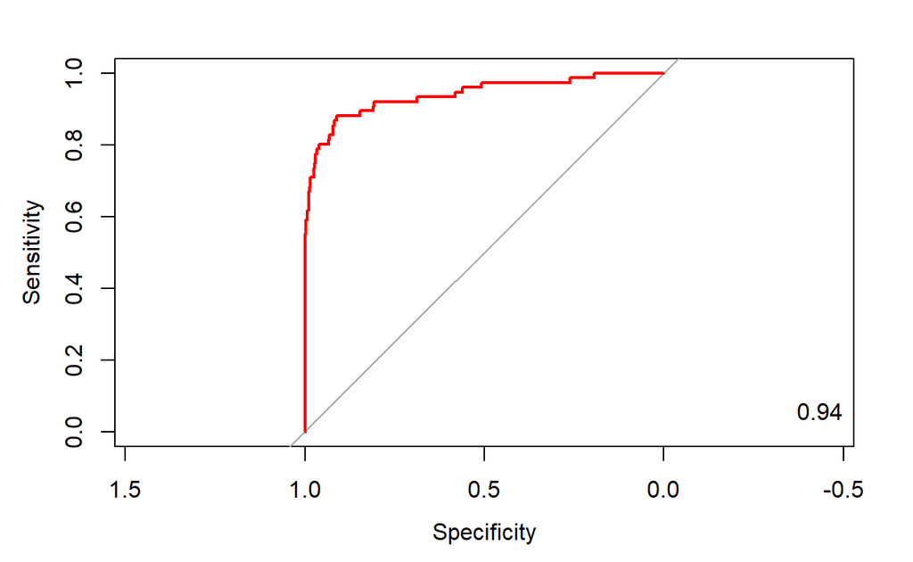

```
pacman::p_load("pROC")

ac <- UB.ted$Personal.Loan                                    # 실제 클래스래스
pp <- predict(ksvm.li, UB.ted, type="prob")[,2]               # "1"에 대한 예측 확률


ksvm.li.roc <- roc(ac, pp, plot=T, col="red")                 # roc(실제 클래스, 예측 확률)률)

auc <- round(auc(ksvm.li.roc), 3)                             # AUC
legend("bottomright",legend=auc, bty="n")
```

```
detach(package:pROC)
```

##### **2) Package “Epi”**

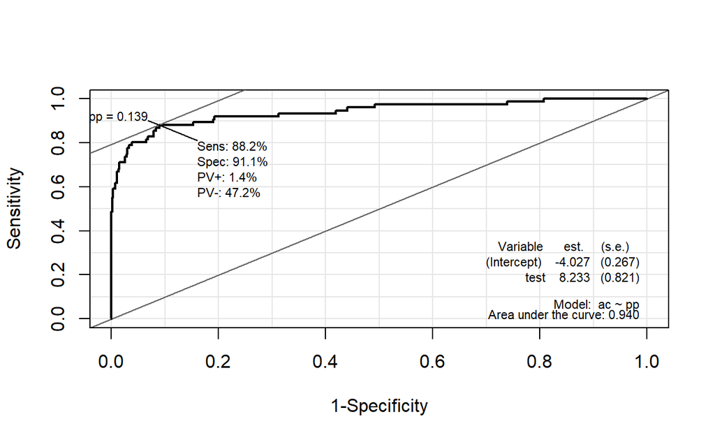

```
# install.packages("Epi")
pacman::p_load("Epi")
# install_version("etm", version = "1.1", repos = "http://cran.us.r-project.org")

ROC(pp,ac, plot="ROC")       # ROC(예측 확률 , 실제 클래스)
```

```
detach(package:Epi)
```

##### **3) Package “ROCR”**

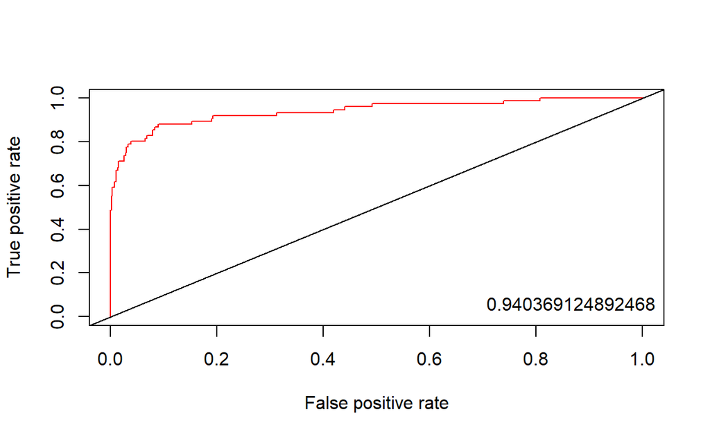

```
pacman::p_load("ROCR")

ksvm.li.pred <- prediction(pp, ac)                         # prediction(예측 확률, 실제 클래스)스)

ksvm.li.perf <- performance(ksvm.li.pred, "tpr", "fpr")    # performance(, "민감도", "1-특이도")
plot(ksvm.li.perf, col="red")                              # ROC Curve
abline(0,1, col="black")


perf.auc <- performance(ksvm.li.pred, "auc")               # AUC

auc <- attributes(perf.auc)$y.values
legend("bottomright",legend=auc,bty="n")
```

#### **향상 차트**

##### **1) Package “ROCR”**

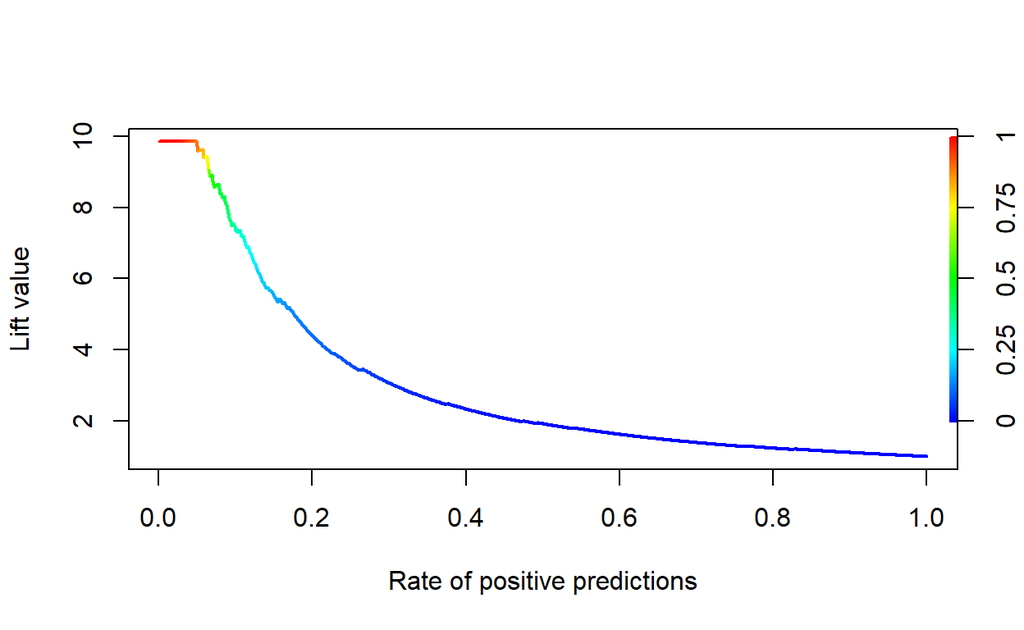

```
li.lift <- performance(ksvm.li.pred,"lift", "rpp")        # Lift chart
plot(li.lift, colorize=T, lwd=2)
```

```
detach(package:ROCR)
```

##### **2) Package “lift”**

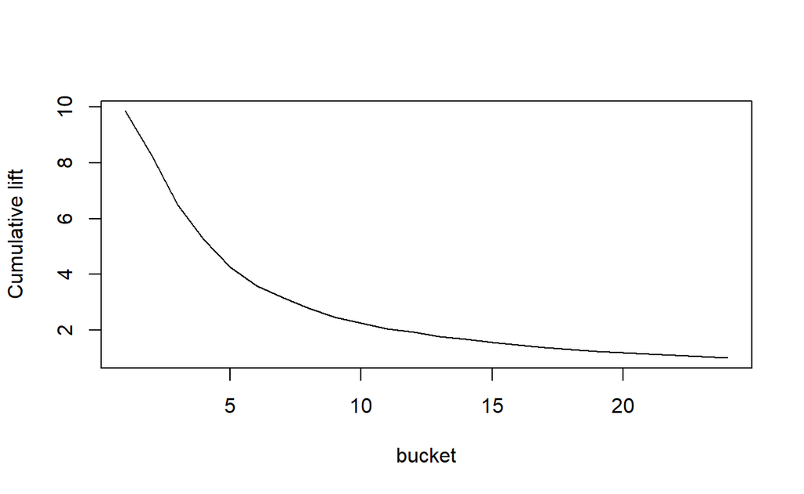

```
# install.packages("lift")
pacman::p_load("lift")

plotLift(pp, ac, cumulative = T, n.buckets =24)      # plotLift(예측 확률, 실제 클래스)스)
```

```
TopDecileLift(pp, ac)                                # Top 10% 향상도 출력
```

```
[1] 7.359
```

```
detach(package:lift)
```

## **4-2. Radial Basis Kernel**

### **4-2-1. 모형 적합**

```
set.seed(200)
ksvm.nl <- ksvm(Personal.Loan ~.,
                data=UB.trd,
                C=10,
                cross=10,
                kernel="rbfdot",          # knernel = "rbfdot" (Radial Basis kernel "Gaussian") /  자동적으로 최적의 gamma값을 찾음NA=TRUE)


ksvm.nl
```

```
Support Vector Machine object of class "ksvm"

SV type: C-svc  (classification)
 parameter : cost C = 10

Gaussian Radial Basis kernel function.
 Hyperparameter : sigma =  0.0987038664607438

Number of Support Vectors : 236

Objective Function Value : -628.1175
Training error : 0.006282
Cross validation error : 0.029695
Probability model included.
```

### **4-2-2. 모형 평가**

```
# 적합된 모형에 대하여 Test Data 예측NAksvm.nl.pred <- predict(ksvm.nl, UB.ted)  # predict(svm모형, Test Data)
```

#### **ConfusionMatrix**

```
pacman::p_load("caret")


confusionMatrix(ksvm.nl.pred, UB.ted$Personal.Loan, positive="1")    # confusionMatrix(예측 클래스, 실제 클래스, positive = "관심 클래스") 클래스")
```

```
Confusion Matrix and Statistics

          Reference
Prediction   0   1
         0 668  17
         1   5  59

               Accuracy : 0.9706
                 95% CI : (0.9559, 0.9815)
    No Information Rate : 0.8985
    P-Value [Acc > NIR] : 3.493e-14

                  Kappa : 0.8268

 Mcnemar's Test P-Value : 0.01902

            Sensitivity : 0.77632
            Specificity : 0.99257
         Pos Pred Value : 0.92188
         Neg Pred Value : 0.97518
             Prevalence : 0.10147
         Detection Rate : 0.07877
   Detection Prevalence : 0.08545
      Balanced Accuracy : 0.88444

       'Positive' Class : 1
```

```
detach(package:caret)
```

#### **ROC 곡선**

##### **1) Package “pROC”**

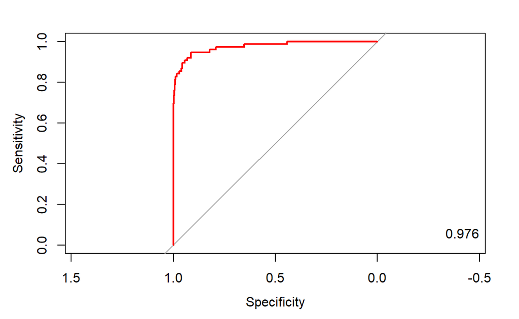

```
pacman::p_load("pROC")

ac <- UB.ted$Personal.Loan                                    # 실제 클래스래스
pp <- predict(ksvm.nl, UB.ted, type="prob")[,2]               # "1"에 대한 예측 확률


ksvm.nl.roc <- roc(ac, pp, plot=T, col="red")                 # roc(실제 클래스, 예측 확률)률)

auc <- round(auc(ksvm.nl.roc), 3)                             # AUC
legend("bottomright",legend=auc, bty="n")
```

```
detach(package:pROC)
```

##### **2) Package “Epi”**

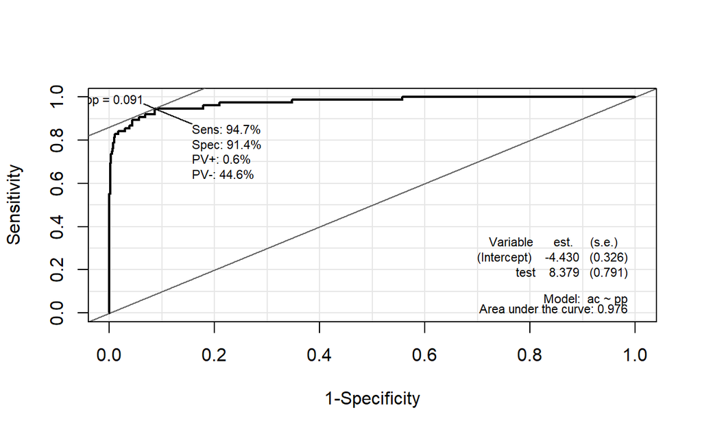

```
# install.packages("Epi")
pacman::p_load("Epi")
# install_version("etm", version = "1.1", repos = "http://cran.us.r-project.org")

ROC(pp,ac, plot="ROC")       # ROC(예측 확률 , 실제 클래스)
```

```
detach(package:Epi)
```

##### **3) Package “ROCR”**

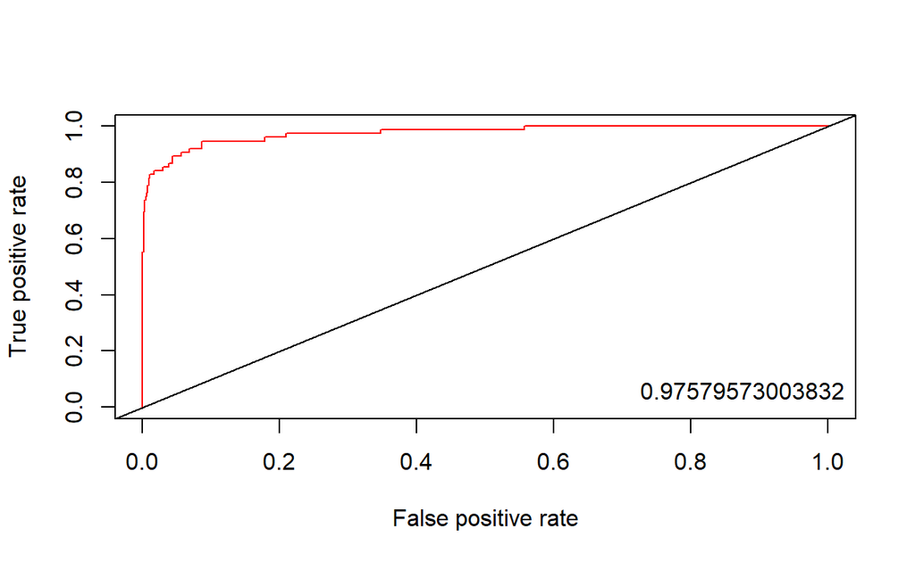

```
pacman::p_load("ROCR")

ksvm.nl.pred <- prediction(pp, ac)                         # prediction(예측 확률, 실제 클래스)스)

ksvm.nl.perf <- performance(ksvm.nl.pred, "tpr", "fpr")    # performance(, "민감도", "1-특이도")
plot(ksvm.nl.perf, col="red")                              # ROC Curve
abline(0,1, col="black")


perf.auc <- performance(ksvm.nl.pred, "auc")               # AUC

auc <- attributes(perf.auc)$y.values
legend("bottomright",legend=auc,bty="n")
```

#### **향상 차트**

##### **1) Package “ROCR”**

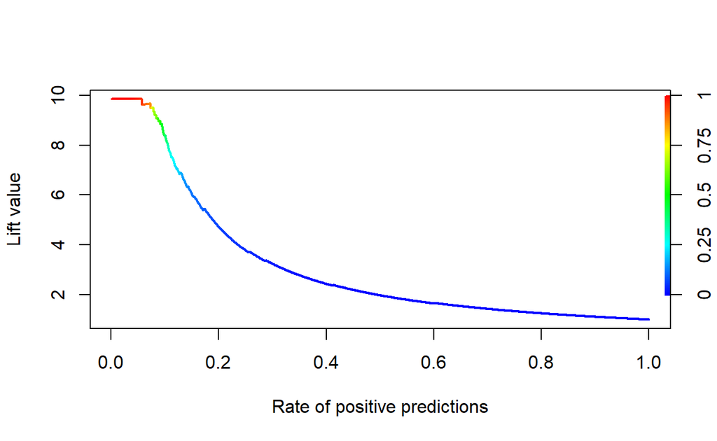

```
nl.lift <- performance(ksvm.nl.pred,"lift", "rpp")        # Lift chart
plot(nl.lift, colorize=T, lwd=2)
```

```
detach(package:ROCR)
```

##### **2) Package “lift”**

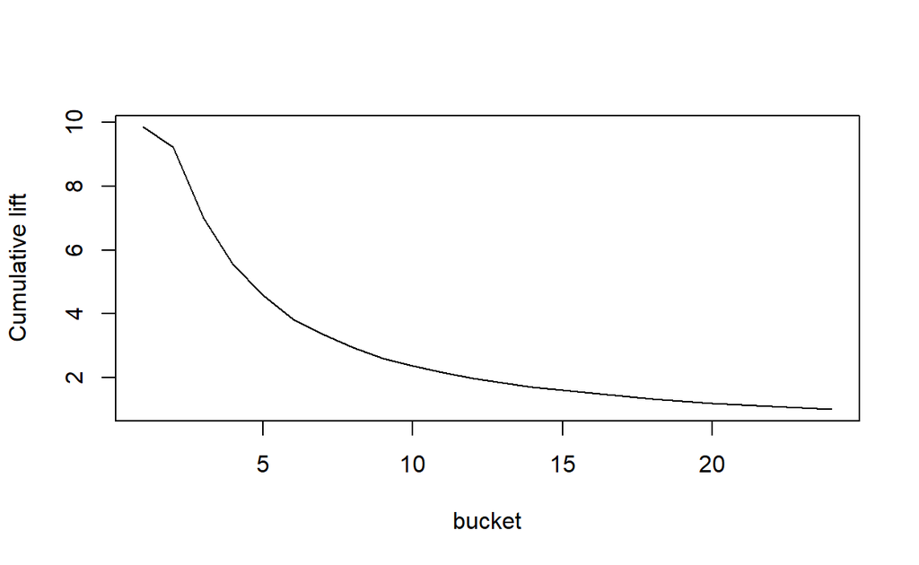

```
# install.packages("lift")
pacman::p_load("lift")

plotLift(pp, ac, cumulative = T, n.buckets =24)      # plotLift(예측 확률, 실제 클래스)스)
```

```
TopDecileLift(pp, ac)                                # Top 10% 향상도 출력
```

```
[1] 8.41
```

```
detach(package:lift)
```

## **4-3. 모형 비교**

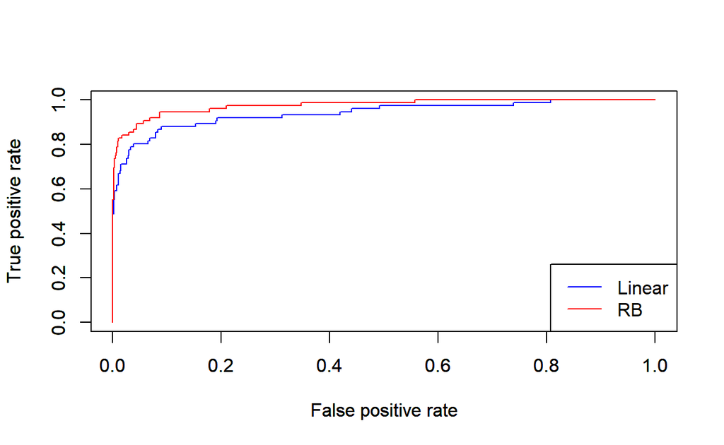

```
plot(ksvm.li.perf, col="blue")         # ROC Curve
par(new=TRUE)
plot(ksvm.nl.perf, col="red")          # ROC Curve

legend("bottomright", legend=c("Linear", "RB"), col=c("blue", "red"), lty=c(1,1))
```

- Radial Basis Kernel이 더 우수한 것을 알 수 있다.

# **5. svm과 ksvm 모형 비교**

## **5-1. 예측 오차**

```
pacman::p_load("tidyverse")

# 예측 클래스래스
svm.li.best.pred <- predict(svm.li.best, newdata=UB.ted, probability=T)
svm.nl.best.pred <- predict(svm.nl.best, newdata=UB.ted, probability=T)
ksvm.li.pred <- predict(ksvm.li, UB.ted)
ksvm.nl.pred <- predict(ksvm.nl, UB.ted)


prev.class <- data.frame(svm.li= svm.li.best.pred, svm.rbf=svm.nl.best.pred,
                         ksvm.li=ksvm.li.pred, ksvm.rbf=ksvm.nl.pred,obs=UB.ted$Personal.Loan)


prev.class %>%
  summarise_all(funs(err=mean(obs!=.))) %>%
  select(-obs_err) %>%
  round(3)
```

```
  svm.li_err svm.rbf_err ksvm.li_err ksvm.rbf_err
1      0.047       0.029       0.047        0.029
```

## **5-2. ROC 곡선**

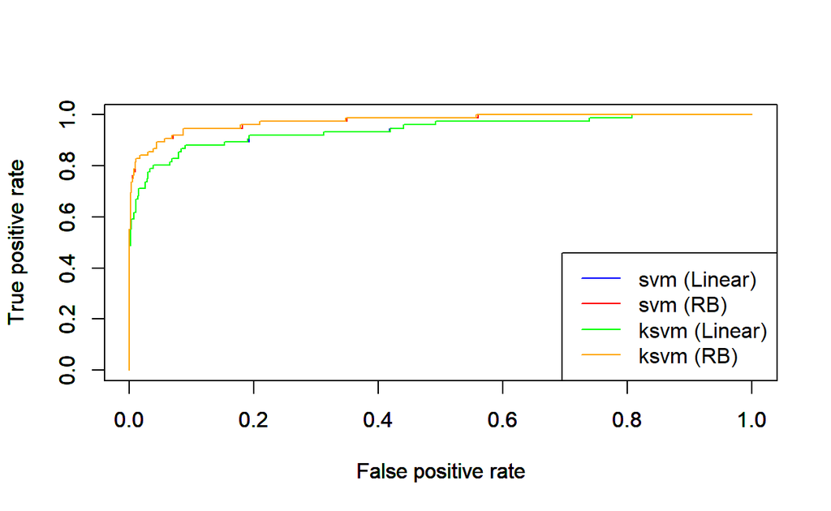

```
pacman::p_load("plotROC")


plot(svm.li.perf, col="blue")         # ROC Curve
par(new=TRUE)
plot(svm.nl.perf, col="red")          # ROC Curve
par(new=TRUE)
plot(ksvm.li.perf, col="green")       # ROC Curve
par(new=TRUE)
plot(ksvm.nl.perf, col="orange")      # ROC Curve

legend("bottomright", legend=c("svm (Linear)", "svm (RB)", "ksvm (Linear)", "ksvm (RB)" ),
       col=c("blue", "red", "green", "orange"), lty=c(1,1,1,1))
```